# Outlier_tests

Koppu Aditya

2022-08-19

## Getting to know data

- Melborn data from Kaggle: https://www.kaggle.com/datasets/anthonypino/melbourne-housing-market?select=Melbourne_housing_FULL.csv

```r
Melbourn = read_csv("./Data/Melbourne_housing_FULL.csv")
```

### Data Exploration

```r
skim(Melbourn)
```

Data summary

| Name | Melbourn |
| --- | --- |
| Number of rows | 34857 |
| Number of columns | 21 |
| _______________________ |  |
| Column type frequency: |  |
| character | 8 |
| numeric | 13 |
| ________________________ |  |
| Group variables | None |

**Variable type: character**

| skim_variable | n_missing | complete_rate | min | max | empty | n_unique | whitespace |
| --- | --- | --- | --- | --- | --- | --- | --- |
| Suburb | 0 | 1 | 3 | 18 | 0 | 351 | 0 |
| Address | 0 | 1 | 8 | 27 | 0 | 34009 | 0 |
| Type | 0 | 1 | 1 | 1 | 0 | 3 | 0 |
| Method | 0 | 1 | 1 | 2 | 0 | 9 | 0 |
| SellerG | 0 | 1 | 1 | 27 | 0 | 388 | 0 |
| Date | 0 | 1 | 9 | 10 | 0 | 78 | 0 |
| CouncilArea | 0 | 1 | 4 | 30 | 0 | 34 | 0 |
| Regionname | 0 | 1 | 4 | 26 | 0 | 9 | 0 |

**Variable type: numeric**

| skim_variable | n_missing | complete_rate | mean | sd | p0 | p25 | p50 | p75 | p100 | hist |
| --- | --- | --- | --- | --- | --- | --- | --- | --- | --- | --- |
| Rooms | 0 | 1.00 | 3.03 | 0.97 | 1.00 | 2.00 | 3.00 | 4.00 | 16.00 | ▇▁▁▁▁ |
| Price | 7610 | 0.78 | 1050173.34 | 641467.13 | 85000.00 | 635000.00 | 870000.00 | 1295000.00 | 11200000.00 | ▇▁▁▁▁ |
| Distance | 1 | 1.00 | 11.18 | 6.79 | 0.00 | 6.40 | 10.30 | 14.00 | 48.10 | ▇▇▂▁▁ |
| Postcode | 1 | 1.00 | 3116.06 | 109.02 | 3000.00 | 3051.00 | 3103.00 | 3156.00 | 3978.00 | ▇▁▁▁▁ |
| Bedroom2 | 8217 | 0.76 | 3.08 | 0.98 | 0.00 | 2.00 | 3.00 | 4.00 | 30.00 | ▇▁▁▁▁ |
| Bathroom | 8226 | 0.76 | 1.62 | 0.72 | 0.00 | 1.00 | 2.00 | 2.00 | 12.00 | ▇▁▁▁▁ |
| Car | 8728 | 0.75 | 1.73 | 1.01 | 0.00 | 1.00 | 2.00 | 2.00 | 26.00 | ▇▁▁▁▁ |
| Landsize | 11810 | 0.66 | 593.60 | 3398.84 | 0.00 | 224.00 | 521.00 | 670.00 | 433014.00 | ▇▁▁▁▁ |
| BuildingArea | 21115 | 0.39 | 160.26 | 401.27 | 0.00 | 102.00 | 136.00 | 188.00 | 44515.00 | ▇▁▁▁▁ |
| YearBuilt | 19306 | 0.45 | 1965.29 | 37.33 | 1196.00 | 1940.00 | 1970.00 | 2000.00 | 2106.00 | ▁▁▁▂▇ |
| Lattitude | 7976 | 0.77 | -37.81 | 0.09 | -38.19 | -37.86 | -37.81 | -37.75 | -37.39 | ▁▂▇▁▁ |
| Longtitude | 7976 | 0.77 | 145.00 | 0.12 | 144.42 | 144.93 | 145.01 | 145.07 | 145.53 | ▁▁▇▂▁ |
| Propertycount | 3 | 1.00 | 7572.89 | 4428.09 | 83.00 | 4385.00 | 6763.00 | 10412.00 | 21650.00 | ▅▇▅▂▁ |

### Applying Basic filters

```r
Melbourn %<>% select(which(colMeans(!is.na(Melbourn)) > 0.5)) %<>% filter( !(is.na(Price)) , Price > 10, !is.na(Landsize), Landsize > 10) %<>%
  mutate('Price_per_area' = Price/Landsize) %<>% filter(Price_per_area < 15000)
```

### Univariate plots

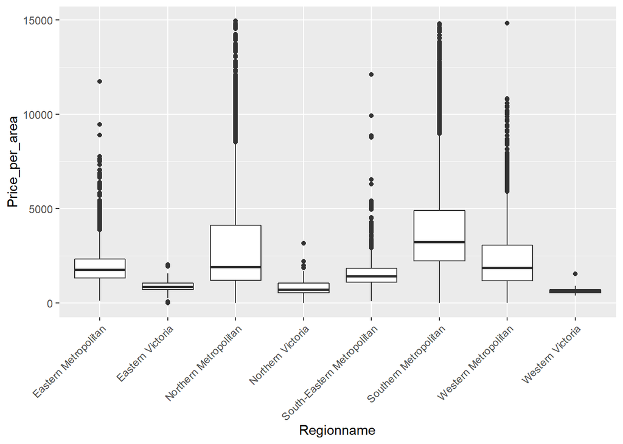

```r
Melbourn %>% ggplot(aes(x=Regionname, y = Price_per_area))+geom_boxplot()+theme(axis.text.x = element_text(angle = 45, hjust=1))
```

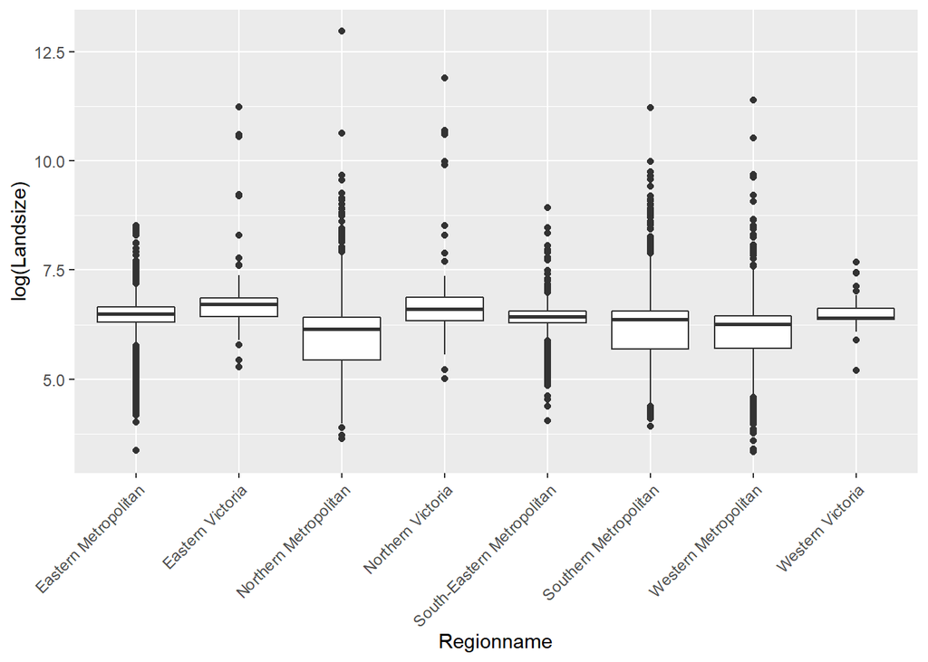

```r
Melbourn %>% ggplot(aes(x=Regionname, y = log(Landsize)))+geom_boxplot()+theme(axis.text.x = element_text(angle = 45, hjust=1))
```

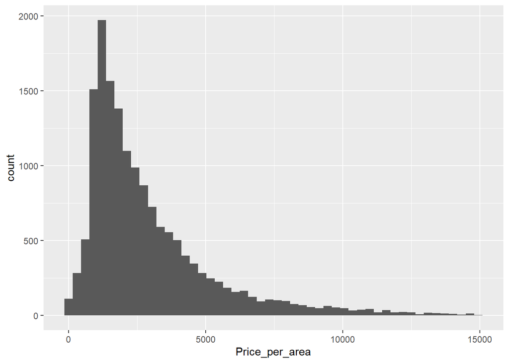

```r
Melbourn %>% ggplot(aes(x= Price_per_area))+geom_histogram(bins= 50)
```

## Simple Statistical Univariate rules

### Z score

The standard score or Z-score is the number of standard deviations by which the value of a raw score (i.e., an observed value or data point) is above or below the mean value of what is being observed or measured. Raw scores above the mean have positive standard scores, while those below the mean have negative standard scores.

Formula is
$$z = \frac{x
-\overline{x}}{\sigma}$$
where $\overline{x}$ is mean of obs and $\sigma$ is sd of obs

Usually anything more than 2 times the sd away is an outlier in data.

#### Normal distribution

[figure not shown]

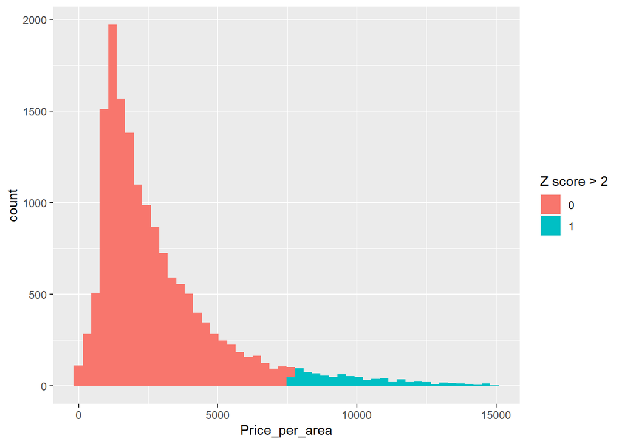

```r
Melbourn %<>% mutate("Z_score" = (Price_per_area - mean(Price_per_area))/sd(Price_per_area), "Z_score_grt_than_2" = as.numeric(Z_score > 2))

Melbourn %>% ggplot(aes(x= Price_per_area, fill = as.factor(Z_score_grt_than_2)))+geom_histogram(bins= 50)+labs(fill = "Z score > 2")
```

```r
Melbourn %>% mutate('Z_score_' = ifelse(Z_score > 2,  "> 2", "<= 2") ) %>%  tabyl(Regionname, Z_score_) %>%  adorn_totals(c("row", "col")) %>%
  adorn_percentages("row") %>%
  adorn_pct_formatting(rounding = "half up", digits = 0) %>%
  adorn_ns() %>%
  adorn_title("combined")%>%
  knitr::kable()
```

| Regionname/Z_score_ | <= 2 | > 2 | Total |
| --- | --- | --- | --- |
| Eastern Metropolitan | 100% (2085) | 0% (5) | 100% (2090) |
| Eastern Victoria | 100% (105) | 0% (0) | 100% (105) |
| Northern Metropolitan | 91% (4135) | 9% (406) | 100% (4541) |
| Northern Victoria | 100% (105) | 0% (0) | 100% (105) |
| South-Eastern Metropolitan | 99% (780) | 1% (4) | 100% (784) |
| Southern Metropolitan | 90% (4080) | 10% (437) | 100% (4517) |
| Western Metropolitan | 99% (3691) | 1% (40) | 100% (3731) |
| Western Victoria | 100% (67) | 0% (0) | 100% (67) |
| Total | 94% (15048) | 6% (892) | 100% (15940) |

### InterQuartile Range(IQR)

$$IQR = Q_3 - Q_1$$
where given 2n/2n+1 numbers

- first quartile $Q_1$ Median of n smallest values
- third quartile $Q_3$ Median of n largest values

Usually $Q_1 +/- (1.5*IQR)$ is considered to be an outlier. In our case, we considered $2*IQR$ as outliers.

[figure not shown]

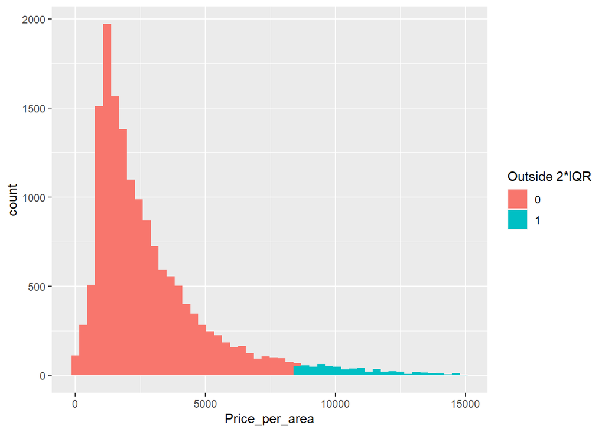

```r
lowerq = quantile(Melbourn$Price_per_area)[2]
upperq = quantile(Melbourn$Price_per_area)[4]
iqr = upperq -lowerq
threshold.upper = (iqr*2) + upperq
threshold.lower = lowerq - (iqr*2)

Melbourn %>% mutate("Outside_threshold" = ifelse(Price_per_area > threshold.upper | Price_per_area < threshold.lower , 1, 0)) %>% ggplot(aes(x= Price_per_area, fill = as.factor(Outside_threshold)))+geom_histogram(bins= 50)+labs(fill = "Outside 2*IQR")
```

```r
Melbourn %>% mutate('IQR_' = ifelse(Price_per_area > threshold.upper | Price_per_area < threshold.lower , ">2", "<2")) %>%  tabyl(Regionname, IQR_) %>%  adorn_totals(c("row", "col")) %>%
  adorn_percentages("row") %>%
  adorn_pct_formatting(rounding = "half up", digits = 0) %>%
  adorn_ns() %>%
  adorn_title("combined")%>%
  knitr::kable()
```

| Regionname/IQR_ | <2 | >2 | Total |
| --- | --- | --- | --- |
| Eastern Metropolitan | 100% (2087) | 0% (3) | 100% (2090) |
| Eastern Victoria | 100% (105) | 0% (0) | 100% (105) |
| Northern Metropolitan | 94% (4248) | 6% (293) | 100% (4541) |
| Northern Victoria | 100% (105) | 0% (0) | 100% (105) |
| South-Eastern Metropolitan | 99% (780) | 1% (4) | 100% (784) |
| Southern Metropolitan | 93% (4190) | 7% (327) | 100% (4517) |
| Western Metropolitan | 99% (3703) | 1% (28) | 100% (3731) |
| Western Victoria | 100% (67) | 0% (0) | 100% (67) |
| Total | 96% (15285) | 4% (655) | 100% (15940) |

### Hamples filter

If a point exceeds the sum of median and 3*(Median Absolute deviation) then it is considered an outlier. This method is usually used in timeseries by selecting a window size to be considered for sliding window.

$$outlier = median +/- 3*MAD$$

where
$$MAD = \frac{1}{n} \Sigma|x_i -
median(X)|$$

## Statistical tests

### Rosner’s test

Details: https://alexkowa.github.io/EnvStats/reference/rosnerTest.html

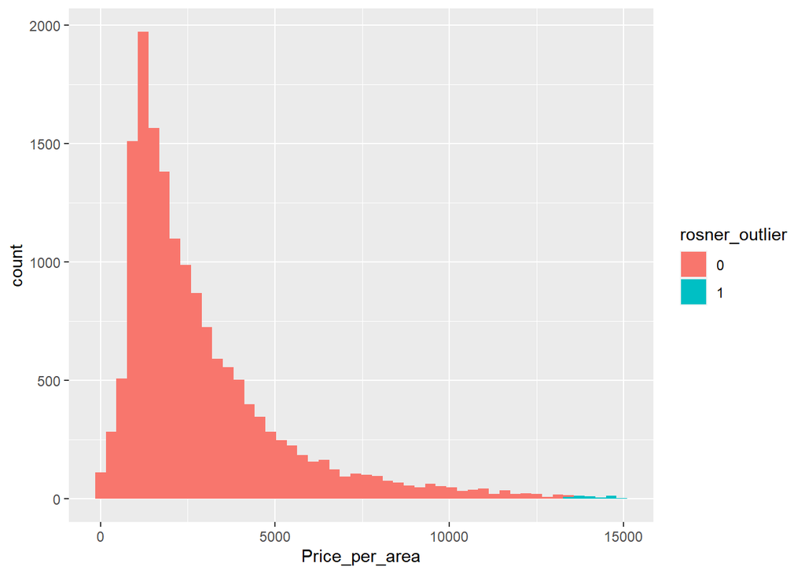

```r
test <- rosnerTest(x =c(Melbourn$Price_per_area),
                   k = 1000,
                   alpha = 0.05,
                   warn = F
)
Outlier_indices = as_tibble(test$all.stats) %>% filter(Outlier == TRUE) %>% select(Obs.Num)

Melbourn %>% mutate("rosner_outlier" =  ifelse(row_number() %in% Outlier_indices$Obs.Num,1,0)) %>% ggplot(aes(x= Price_per_area, fill = as.factor(rosner_outlier)))+geom_histogram(bins= 50)+labs(fill = "rosner_outlier")
```

```r
Melbourn %>% mutate("rosner_outlier" =  ifelse(row_number() %in% Outlier_indices$Obs.Num,1,0)) %>%  tabyl(Regionname, rosner_outlier) %>%  adorn_totals(c("row", "col")) %>%
  adorn_percentages("row") %>%
  adorn_pct_formatting(rounding = "half up", digits = 0) %>%
  adorn_ns() %>%
  adorn_title("combined")%>%
  knitr::kable()
```

| Regionname/rosner_outlier | 0 | 1 | Total |
| --- | --- | --- | --- |
| Eastern Metropolitan | 100% (2090) | 0% (0) | 100% (2090) |
| Eastern Victoria | 100% (105) | 0% (0) | 100% (105) |
| Northern Metropolitan | 99% (4514) | 1% (27) | 100% (4541) |
| Northern Victoria | 100% (105) | 0% (0) | 100% (105) |
| South-Eastern Metropolitan | 100% (784) | 0% (0) | 100% (784) |
| Southern Metropolitan | 99% (4489) | 1% (28) | 100% (4517) |
| Western Metropolitan | 100% (3730) | 0% (1) | 100% (3731) |
| Western Victoria | 100% (67) | 0% (0) | 100% (67) |
| Total | 100% (15884) | 0% (56) | 100% (15940) |

```r
#Building quick regression. Check missing values
Melbourn.model.df = Melbourn %>% mutate('Car_per_Bedrooms' = Car/Bedroom2, 'Car_per_Bedrooms' = ifelse(is.infinite(Car_per_Bedrooms) | is.na(Car_per_Bedrooms), median(Car_per_Bedrooms, na.rm = T), Car_per_Bedrooms), 'Rooms_per_Landsize' = Rooms/Landsize, 'Date' = lubridate::dmy(Date), 'Year_sold' = lubridate::year(Date))%>% select(-c("Address", "Price", "Lattitude", "Longtitude", "Postcode", "Z_score_grt_than_2", "Z_score", "Bedroom2", "Car")) %>% filter(!(is.na(Bathroom))) %>% mutate_if(is.character, as.factor) %>% select(-c("Suburb", "SellerG"))

skim(Melbourn.model.df)
```

Data summary

| Name | Melbourn.model.df |
| --- | --- |
| Number of rows | 15931 |
| Number of columns | 14 |
| _______________________ |  |
| Column type frequency: |  |
| Date | 1 |
| factor | 4 |
| numeric | 9 |
| ________________________ |  |
| Group variables | None |

**Variable type: Date**

| skim_variable | n_missing | complete_rate | min | max | median | n_unique |
| --- | --- | --- | --- | --- | --- | --- |
| Date | 0 | 1 | 2016-01-28 | 2018-03-17 | 2017-06-17 | 78 |

**Variable type: factor**

| skim_variable | n_missing | complete_rate | ordered | n_unique | top_counts |
| --- | --- | --- | --- | --- | --- |
| Type | 0 | 1 | FALSE | 3 | h: 13371, u: 1411, t: 1149 |
| Method | 0 | 1 | FALSE | 5 | S: 10551, SP: 1970, PI: 1866, VB: 1426 |
| CouncilArea | 0 | 1 | FALSE | 33 | Bor: 1474, Dar: 1425, Mor: 1070, Moo: 1002 |
| Regionname | 0 | 1 | FALSE | 8 | Nor: 4539, Sou: 4514, Wes: 3729, Eas: 2090 |

**Variable type: numeric**

| skim_variable | n_missing | complete_rate | mean | sd | p0 | p25 | p50 | p75 | p100 | hist |
| --- | --- | --- | --- | --- | --- | --- | --- | --- | --- | --- |
| Rooms | 0 | 1 | 3.18 | 0.88 | 1.00 | 3.00 | 3.00 | 4.00 | 12.00 | ▇▃▁▁▁ |
| Distance | 0 | 1 | 11.73 | 6.72 | 0.00 | 7.20 | 10.80 | 14.30 | 48.10 | ▇▇▂▁▁ |
| Bathroom | 0 | 1 | 1.62 | 0.71 | 0.00 | 1.00 | 2.00 | 2.00 | 9.00 | ▇▇▁▁▁ |
| Landsize | 0 | 1 | 669.05 | 3985.52 | 28.00 | 306.00 | 555.00 | 685.00 | 433014.00 | ▇▁▁▁▁ |
| Propertycount | 0 | 1 | 7379.95 | 4406.57 | 83.00 | 4217.00 | 6482.00 | 10175.00 | 21650.00 | ▅▇▅▂▁ |
| Price_per_area | 0 | 1 | 2903.80 | 2348.41 | 6.24 | 1308.81 | 2164.87 | 3693.27 | 14950.98 | ▇▃▁▁▁ |
| Car_per_Bedrooms | 0 | 1 | 0.57 | 0.33 | 0.00 | 0.33 | 0.50 | 0.67 | 9.00 | ▇▁▁▁▁ |
| Rooms_per_Landsize | 0 | 1 | 0.01 | 0.01 | 0.00 | 0.00 | 0.01 | 0.01 | 0.06 | ▇▂▁▁▁ |
| Year_sold | 0 | 1 | 2016.83 | 0.66 | 2016.00 | 2016.00 | 2017.00 | 2017.00 | 2018.00 | ▅▁▇▁▂ |

### Building LM to predict price per unit area

```r
Melbourn.model.df %<>%  mutate(Landsize_log := log10(Landsize))
cols.idv = c("Distance"
             ,"Regionname"
             ,"Rooms_per_Landsize"
             ,"Bathroom"
             ,"Type"
             #,"Propertycount"
             ,"Landsize_log"

)

mod <- lm(as.formula(paste0("Price_per_area~",paste0(cols.idv,collapse = "+" ))), data = Melbourn.model.df)

tidy(mod) %>% knitr::kable()
```

| term | estimate | std.error | statistic | p.value |
| --- | --- | --- | --- | --- |
| (Intercept) | 7041.9476 | 172.279701 | 40.875086 | 0 |
| Distance | -132.1994 | 1.775689 | -74.449627 | 0 |
| RegionnameEastern Victoria | 2074.9557 | 114.167851 | 18.174606 | 0 |
| RegionnameNorthern Metropolitan | -451.0512 | 30.300899 | -14.885736 | 0 |
| RegionnameNorthern Victoria | 1829.3985 | 113.883842 | 16.063723 | 0 |
| RegionnameSouth-Eastern Metropolitan | 914.8775 | 48.759413 | 18.763094 | 0 |
| RegionnameSouthern Metropolitan | 751.8484 | 30.218770 | 24.880179 | 0 |
| RegionnameWestern Metropolitan | -834.1022 | 30.602117 | -27.256355 | 0 |
| RegionnameWestern Victoria | 1022.7646 | 138.106488 | 7.405623 | 0 |
| Rooms_per_Landsize | 240992.3603 | 3261.877557 | 73.881486 | 0 |
| Bathroom | 194.1638 | 13.472876 | 14.411460 | 0 |
| Typet | -909.1517 | 35.779101 | -25.410134 | 0 |
| Typeu | -1163.8624 | 31.425444 | -37.035670 | 0 |
| Landsize_log | -1735.6330 | 56.985015 | -30.457709 | 0 |

```r
glance(mod) %>%  knitr::kable()
```

| r.squared | adj.r.squared | sigma | statistic | p.value | df | logLik | AIC | BIC | deviance | df.residual | nobs |
| --- | --- | --- | --- | --- | --- | --- | --- | --- | --- | --- | --- |
| 0.7856327 | 0.7854577 | 1087.752 | 4487.237 | 0 | 13 | -133985.6 | 268001.1 | 268116.3 | 18833049609 | 15917 | 15931 |

```r
Melbourn.model.df %<>% mutate("predicted" =  predict(mod,new_data =Melbourn.model.df ), "residuals" = Price_per_area - predicted, "APE" = abs(residuals)/Price_per_area )

Melbourn.model.df %>% summarise('MAPE' = mean(APE), 'count' =n()) %>% knitr::kable()
```

| MAPE | count |
| --- | --- |
| 0.7333169 | 15931 |

## Bonferroni Outlier test

This comes from car Outlier_test Details: https://search.r-project.org/CRAN/refmans/car/html/outlierTest.html

```r
outlierTest(mod) # 10 rows as outlier
```

```
##       rstudent unadjusted p-value Bonferroni p
## 10118 9.635529         6.4960e-22   1.0349e-17
## 89    7.417084         1.2576e-13   2.0034e-09
## 11950 7.392086         1.5172e-13   2.4171e-09
## 2126  7.328634         2.4367e-13   3.8819e-09
## 12699 7.232426         4.9604e-13   7.9023e-09
## 6629  7.224596         5.2537e-13   8.3697e-09
## 6962  7.126221         1.0759e-12   1.7140e-08
## 6742  6.780737         1.2377e-11   1.9718e-07
## 15736 6.745207         1.5807e-11   2.5183e-07
## 8039  6.647173         3.0849e-11   4.9145e-07
```

```r
outlier_rows = outlierTest(mod)$bonf.p %>% as.data.frame() %>% row.names() %>% as.numeric()
Melbourn.model.df %<>% mutate("bonferroni_outliers" = as.factor(row_number() %in% outlier_rows ))

Melbourn.model.df %>% group_by(bonferroni_outliers) %>% summarise(mean(APE), 'count' =n()) %>% knitr::kable()
```

| bonferroni_outliers | mean(APE) | count |
| --- | --- | --- |
| FALSE | 0.7333977 | 15921 |
| TRUE | 0.6045797 | 10 |

### Cooks distance

Cook’s distance or Cook’s D is a commonly used estimate of the influence of a data point when performing a least-squares regression analysis. So, these are not exactly outliers but are influential points. Checking for common features for these points before excluding them will be better.

$$D_i = \frac{\Sigma{(\hat{Y_j} -
\hat{Y_{j(i)}})}^2}{(p+1){\sigma}^2}$$
Where

- $y_j$ — the jth fitted response value.
- $y_{j(i)}$ — the jth fitted response value, where the fit does not include observation i.
- $p$ — the number of regression coefficients
- $\sigma$ — the estimated variance from the fit, based on all observations, i.e. Mean Squared Error

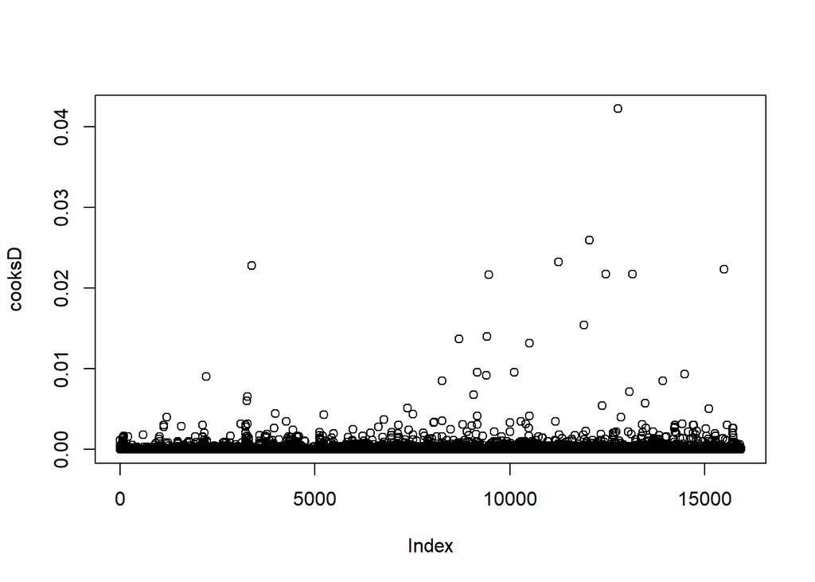

```r
cooksD <- cooks.distance(mod)
influential <- as.numeric(names(cooksD[(cooksD > (3 * mean(cooksD, na.rm = TRUE)))]))

plot(cooksD)
```

The number of points that have > 3 mean are 894

```r
Melbourn.model.df %<>% mutate("cooks_outliers1" = as.factor(row_number() %in% influential ))
Melbourn.model.df %>% group_by(cooks_outliers1) %>% summarise(mean(APE), 'count' =n()) %>% knitr::kable()
```

| cooks_outliers1 | mean(APE) | count |
| --- | --- | --- |
| FALSE | 0.3612071 | 15037 |
| TRUE | 6.9921697 | 894 |

### Isolation Forest

Tree based method. It works to isolate a point or set of identical points as quickly as possible.

Sources: https://scikit-learn.org/stable/modules/generated/sklearn.ensemble.IsolationForest.html

https://medium.com/codex/isolation-forest-outlier-detection-simplified-5d938548bb5c

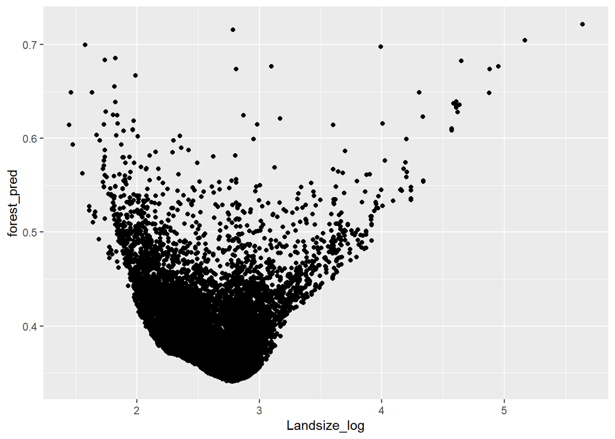

```r
p_load(isotree)

iso_forest =isolation.forest(Melbourn.model.df %>% select(all_of(c(cols.idv, "Price_per_area"))))

Melbourn.model.df$forest_pred <- predict(iso_forest, Melbourn.model.df, type = "score")

Melbourn.model.df %>%  ggplot(aes(x = Landsize_log, y =forest_pred ))+geom_point()
```

```r
Melbourn.model.df %>% group_by(forest_pred >= 0.5) %>% summarise(mean(APE), 'count' =n())
```

```
## # A tibble: 2 × 3
##   `forest_pred >= 0.5` `mean(APE)` count
##   <lgl>                      <dbl> <int>
## 1 FALSE                      0.390 15534
## 2 TRUE                      14.2     397
```